# Tasks 4 -7

Hala

2024-09-20

```r
library(readr)
library(ggplot2)
library(tidyverse)
library(tidybiology)
library(ggpubr)
```

```r
?CO2
```

This dataset contains a data frame of 84 rows and 5 columns of experimental data. The experiment is testing the tolerance of a species of grass for the cold. The 5 columns are: 1- Plant: a unique identifier for each plant 2- Type: the origin of the plant 3- Treatment: cold or not cold condition 4- conc: a measurement of ambient CO2 concentrations in ml/L 5- uptake: a measurement of CO2 uptake in umol/m2 sec.

```r
d <- CO2

mean(d$uptake[d$Type == "Quebec"])
```

```
## [1] 33.54286
```

```r
median(d$uptake[d$Type == "Quebec"])
```

```
## [1] 37.15
```

```r
mean(d$uptake[d$Type == "Mississippi"])
```

```
## [1] 20.88333
```

```r
median(d$uptake[d$Type == "Mississippi"])
```

```
## [1] 19.3
```

In plants from Mississippi: The mean CO2 uptake is 20.88 umol/m2 sec. The median CO2 uptake is 19.3 umol/m2 sec.

```r
ratio <- function(x) {
  avg <- mean(x)
  med <- median(x)
  return(avg/med)
}

ratio(d$uptake[d$Type == "Quebec"])
```

```
## [1] 0.9029033
```

```r
ratio(d$uptake[d$Type == "Mississippi"])
```

```
## [1] 1.082038
```

Above is a function that takes the numeric vector x and returns the mean-to-median ratio. It is tested on CO2 uptake in Quebec and Mississippi.

```r
mean_wo_extremes <- function(x) {
  filtered <- x[x!= min(x) & x!= max(x)]
  return(mean(filtered))
}

mean_wo_extremes(d$uptake[d$Type == "Quebec"])
```

```
## [1] 33.85
```

```r
mean_wo_extremes(d$uptake[d$Type == "Mississippi"])
```

```
## [1] 20.8475
```

Above is a function that takes the numeric vector x and returns the mean of the vector excluding the minimum and maximum values.

##Explanation of the apply family of functions:## This family of functions involves four different functions used to apply an operation in bulk to a data type.

**apply():** used for matrices and data.frames to reiterate functions over rows or columns **lapply():** applies function to each item in a list **sapply():** like lapply, but simplifies output into a vector or matrix **tapply():** applies a function to subsets of a vector, based on a grouping factor.

These functions can be especially useful in my work when I am working with big data that needs reiterative functions for items or columns/rows.

```r
d2 <- read_csv("magic_guys.csv")
```

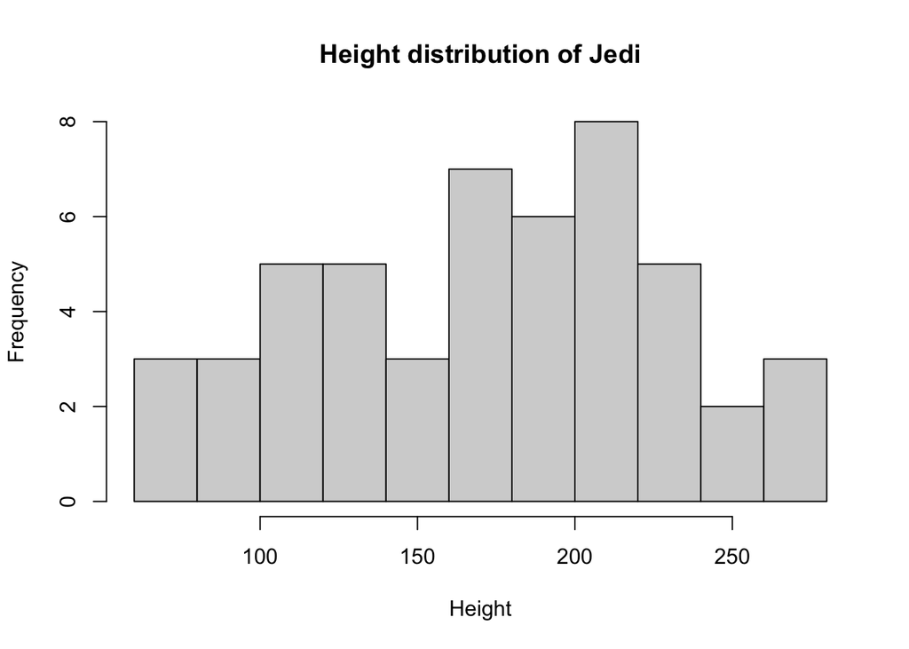

```r
hist(d2$length[d2$species == "jedi"],
     main = "Height distribution of Jedi",
     xlab = "Height",
     breaks = 15)
```

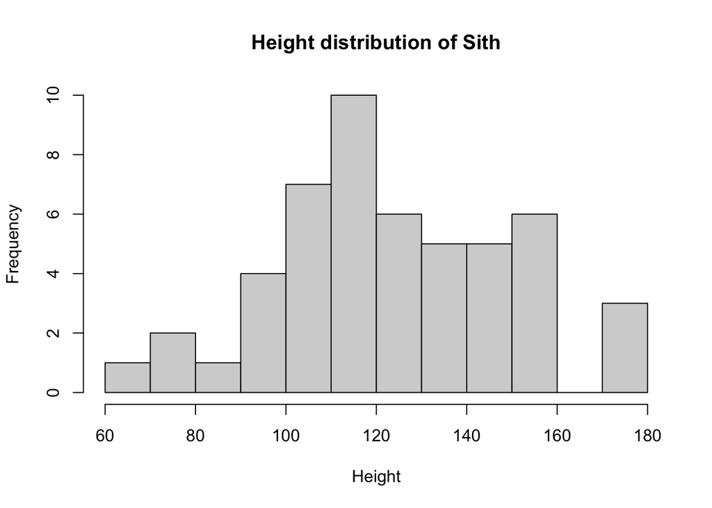

```r
hist(d2$length[d2$species == "sith"],
     main = "Height distribution of Sith",
     xlab = "Height",
     breaks = 15)
```

```r
png(file="r_hist_jedi.png",
width=600, height=350)
hist(d2$length[d2$species == "jedi"],
     main = "Height distribution of Jedi",
     xlab = "Height",
     breaks = 15)
dev.off()
```

```r
png(file="r_hist_sith.png",
width=600, height=350)
hist(d2$length[d2$species == "sith"],
     main = "Height distribution of Sith",
     xlab = "Height",
     breaks = 15)
dev.off()
```

Histographs of height in Jedi and Sith using base r hist function and saved as pngs.

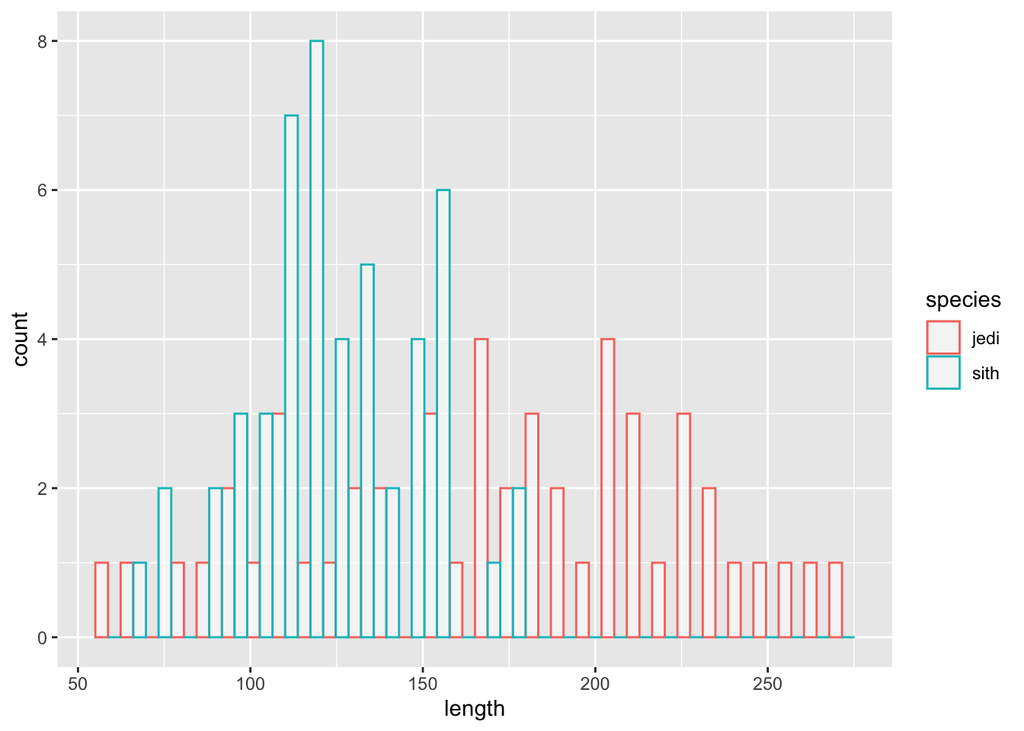

```r
ggplot(d2, aes(x=length, color=species), main = "Test") +
  geom_histogram(fill="white", alpha=0.5, position="dodge")
```

```r
png(file="ggplot_hist.png",
width=600, height=350)
ggplot(d2, aes(x=length, color=species), main = "Test") +
  geom_histogram(fill="white", alpha=0.5, position="dodge")
dev.off()
```

Histographs of height in Jedi and Sith using ggplot histogram function and saved as pngs.

##The difference between ‘png’, ‘pdf’, and ‘svg’ formats##

**png:** used for images with sharp edges or transparency such as logos, graphs, screenshots.

**pdf:** best for documents, reports, or multi-page outputs. Remains vector-based.

*svg:** best for web graphics and icons. scalable and vector-based. Lightweight for websites

```r
d3 <- read.delim("microarray_data.tab", header = TRUE)

ncol(d3)
```

```
## [1] 1000
```

```r
nrow(d3)
```

```
## [1] 553
```

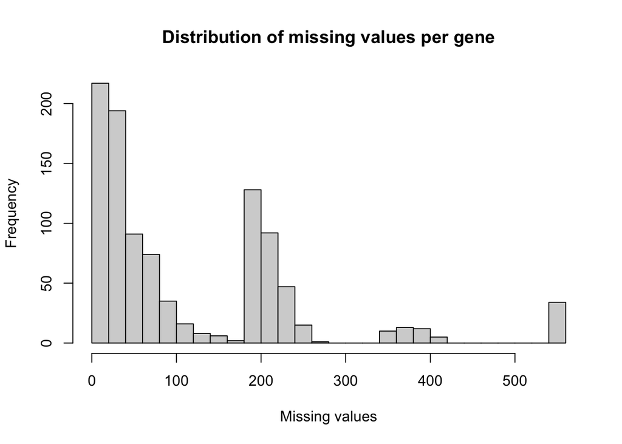

```r
gene_NA <- colSums(is.na(d3))

hist(gene_NA,
     main = "Distribution of missing values per gene",
     xlab = "Missing values",
     breaks = 20
     )
```

```r
which
```

```
## function (x, arr.ind = FALSE, useNames = TRUE)
## {
##     wh <- .Internal(which(x))
##     if (isTRUE(arr.ind) && !is.null(d <- dim(x)))
##         arrayInd(wh, d, dimnames(x), useNames = useNames)
##     else wh
## }
## <bytecode: 0x1504a6f70>
## <environment: namespace:base>
```

```r
threshold_10 <- 0.10 * nrow(d3)
threshold_20 <- 0.20 * nrow(d3)
threshold_50 <- 0.50 * nrow(d3)


genes_10 <- which(colSums(is.na(d3)) > threshold_10)
genes_20 <- which(colSums(is.na(d3)) > threshold_20)
genes_50 <- which(colSums(is.na(d3)) > threshold_50)
```

I made three lists. ‘genes_10’,‘genes_20’, and ‘genes_50’ with genes with more than 10%, 20% and 50% missing values respectively.

```r
d4 <- d3
d4[] <- lapply(d4, function(col) {
  ifelse(is.na(col), mean(col, na.rm = TRUE), col)
})
```

I made a new database d4 and populated it with data from d3, replacing NA’s with the column mean.

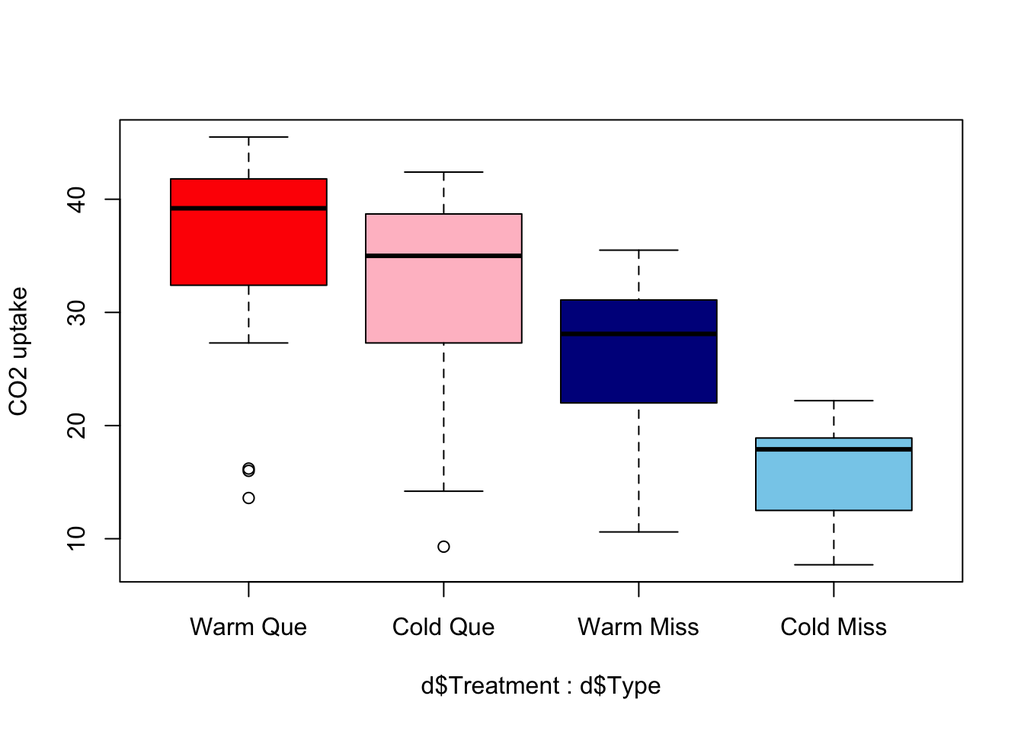

```r
boxplot(d$uptake ~ d$Treatment*d$Type,
        col = c("red", "pink", "darkblue", "skyblue"),
        names = c("Warm Que", "Cold Que",
                   "Warm Miss", "Cold Miss"),
        ylab = "CO2 uptake")
```

Both plants from Quebec and Mississippi reduce CO2 uptake in chilled conditions, which could be a sign of decreased functions. However, a greater reduction is seen in plants from Mississippi. This means that they are more impacted by the weather. The plants in Quebec could be more resistant to cold weather because of the cold Quebecois climate.

```r
chromosome <- chromosome

summary_output <- summary(chromosome$variations)

chromosome %>%
  reframe(
    "Measures" = names(summary_output),
    "Variations" = summary(variations),
    "Protein coding genes"= summary(protein_codinggenes),
    "miRNA" = summary(mi_rna)
  )
```

```
## # A tibble: 6 × 4
##   Measures Variations  `Protein coding genes` miRNA
##   <chr>    <table[1d]> <table[1d]>            <table[1d]>
## 1 Min.       211643      71.0000               15.00000
## 2 1st Qu.   4395298     595.7500               55.75000
## 3 Median    6172346     836.0000               75.00000
## 4 Mean      6484572     849.9583               73.16667
## 5 3rd Qu.   8742592    1055.5000               92.00000
## 6 Max.     12945965    2058.0000              134.00000
```

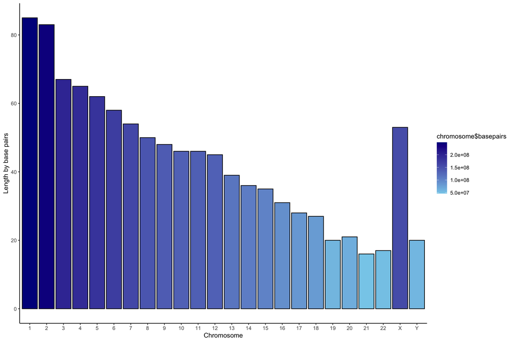

```r
ggplot(data = NULL, aes(x = factor(c(1:22, "X", "Y"), levels = c(1:22, "X", "Y")), y = chromosome$length_mm, fill = chromosome$basepairs)) +
  geom_bar(stat = "identity", color = "black") +
  xlab("Chromosome") +
  ylab("Length by base pairs") +
  scale_fill_gradient(low = "skyblue", high = "darkblue") +
  theme_classic()
```

Chromosomes get smaller with each chromosome, with the key exeption of chromosome X which is similar in size to chromosome 7.

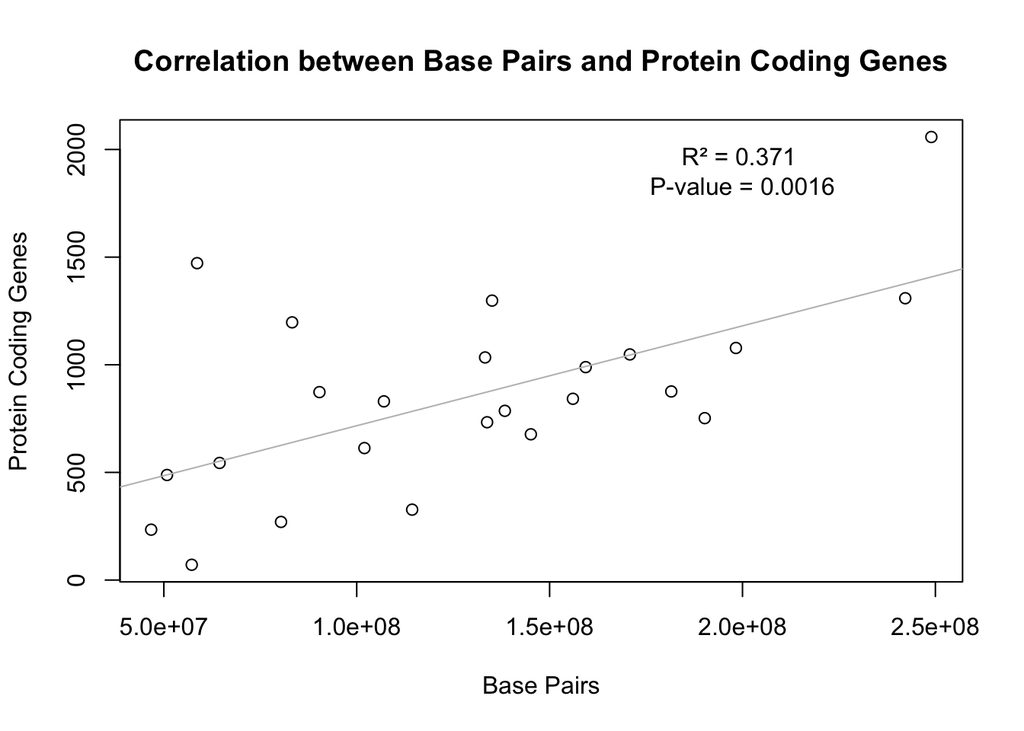

```r
plot(chromosome$protein_codinggenes ~ chromosome$basepairs,
     xlab = "Base Pairs",
     ylab = "Protein Coding Genes",
     main = "Correlation between Base Pairs and Protein Coding Genes")


abline(lm(protein_codinggenes ~ basepairs, data = chromosome), col = "grey")


model <- lm(protein_codinggenes ~ basepairs, data = chromosome)
summary_model <- summary(model)
r_squared <- round(summary_model$r.squared, 3)
p_value <- round(summary_model$coefficients[2,4], 4)
text(x = 200000000,
     y = 1900,
     labels = paste("R² =", r_squared, "\nP-value =", p_value),
     col = "black")
```

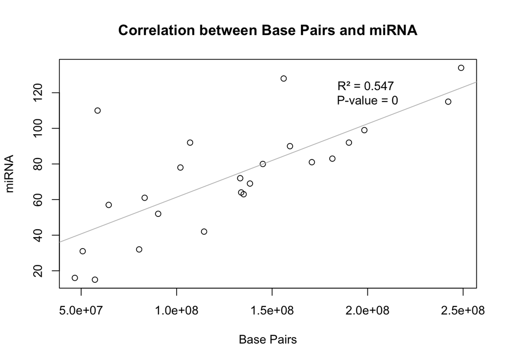

```r
plot(chromosome$mi_rna ~ chromosome$basepairs,
     xlab = "Base Pairs",
     ylab = "miRNA",
     main = "Correlation between Base Pairs and miRNA")


abline(lm(mi_rna ~ basepairs, data = chromosome), col = "grey")


model <- lm(mi_rna ~ basepairs, data = chromosome)
summary_model <- summary(model)
r_squared <- round(summary_model$r.squared, 3)
p_value <- round(summary_model$coefficients[2,4], 4)
text(x = 200000000,
     y = 120,
     labels = paste("R² =", r_squared, "\nP-value =", p_value),
     col = "black")
```

Both measures correlate with chromosome size.

```r
proteins <- proteins

summary_output <- summary(proteins$length)

proteins %>%
  reframe(
    "Measures" = names(summary_output),
    "Length" = summary(length),
    "Mass"= summary(mass)
  )
```

```
## # A tibble: 6 × 3
##   Measures Length      Mass
##   <chr>    <table[1d]> <table[1d]>
## 1 Min.         2.0000      260.00
## 2 1st Qu.    251.0000    27940.25
## 3 Median     414.0000    46140.50
## 4 Mean       557.1603    62061.38
## 5 3rd Qu.    669.0000    74754.75
## 6 Max.     34350.0000  3816030.00
```

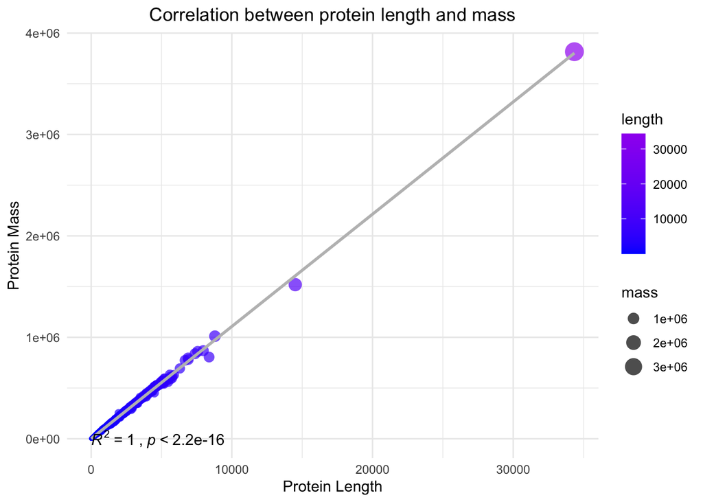

```r
ggplot(proteins, aes(x = length, y = mass)) +
  geom_point(aes(color = length, size = mass), alpha = 0.7, shape = 16) +
  geom_smooth(method = "lm", se = FALSE, color = "grey") +  # Add line of best fit
  stat_cor(aes(label = paste(..rr.label.., ..p.label.., sep = "~`,`~")),
           label.x = 3, label.y = 30) +  # Add R² and p-value
  scale_color_gradient(low = "blue", high = "purple") +
  xlab("Protein Length") +
  ylab("Protein Mass") +
  ggtitle("Correlation between protein length and mass") +
  theme_minimal() +
  theme(plot.title = element_text(hjust = 0.5))
```

Protein length and mass are significantly positively correlated.